# Busca la verdad, desarrolla un tema libre

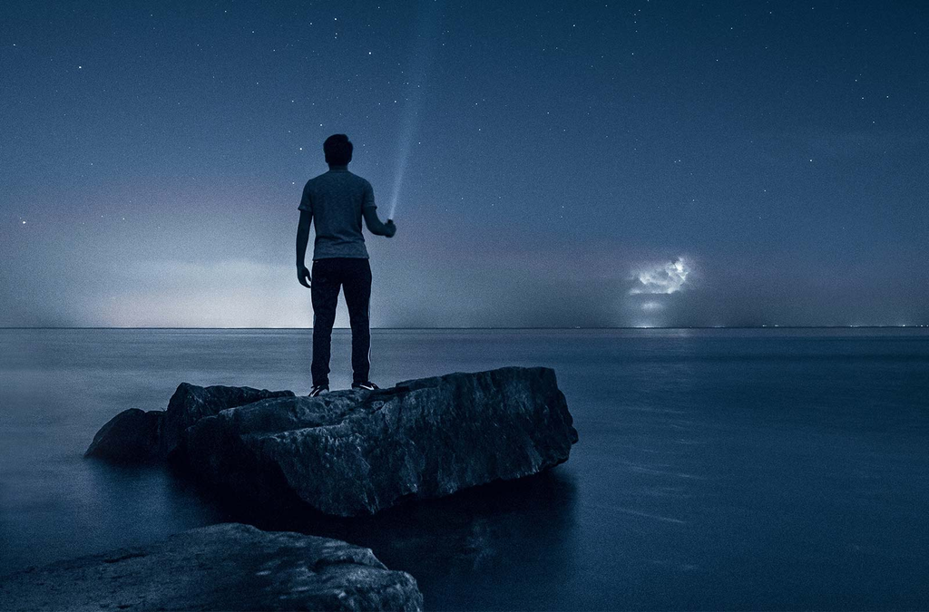

Fuente: roomfordoubt.com

## Buscando la verdad

Siempre estamos buscando la verdad casi de modo inconciente. Esta tiene la capacidad de llenarnos, conformarnos y **comprometernos**. Cuando entendemos algo, cuando algo nos ilumina, también nos impulsa a vivir de acuerdo con eso que vemos como verdadero. Por ejemplo si captamos de un modo profundo la belleza y nobleza de un caballo esto nos mueve a tratarlo bien, a procurarle la comida y el descanso que necesita, a alabar a Dios por haberlo creado, etc.

Este trabajo apunta a que elijas un tema, uno de los que escribiste en la lista, o algún otro que se te ocurra, y busques con sinceridad aprender sobre eso intentado descubrir lo verdadero. El tema elegido tiene que ser interesante para tí y tener una fuerte relación con la parte espiritual y vital del ser humano.

## ¿Qué hay que hacer en concreto?

- Elegir un tema.
- Investigar, esto tiene que llevarte a investigar cosas.
- Buscar al menos una imagen que aporte algo al tema. Se puede tenerla impresa, dibujarla o en el celular.
- Preparar un escrito que sirva de base para una exposición dialogada de al menos 5 minutos para el resto del curso (salvo que el profesor indique lo contrario en algún caso). En la conversación se puede tener y mostrar la imagen pero no el escrito. Este tiene que brotar de adentro.

> **Aclaración:** Desarrollar un tema brevemente requiere más preparación que hacerlo mediante un largo discurso por que requiere ser más precisos y pensar más las palabras. Esto es lo que se pretende aquí.